# Building a flowchart

Max Gordon

2026-06-20

# Flowchart

A flowchart is a type of diagram that represents a workflow or process. In research we often want to explain how we recruited our patients, how many that were available from the start, how many that were excluded and how many were left at the final analysis. The **Gmisc** package provides a convenient set of functions for doing this using the R’s built-in `grid` package with some bells and whistles. Below is a simple example that illustrates what we’re aiming for.

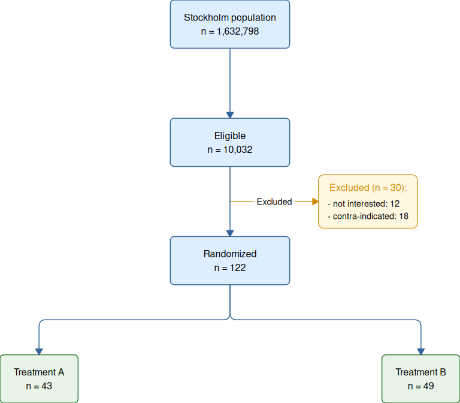

```r
# Shared styling
main_box_gp <- gpar(fill = "#ddeeff", col = "#336699", lwd = 1.5)
group_box_gp <- gpar(fill = "#e8f4e8", col = "#2e7d32", lwd = 1.5)
excl_box_gp  <- gpar(fill = "#fff8e1", col = "#cc8800", lwd = 1.2)
main_con_gp  <- gpar(col = "#336699", lwd = 1.5, fill = "#336699")
excl_con_gp  <- gpar(col = "#cc8800", lwd = 1.2, fill = "#cc8800")

grid.newpage()
flowchart(
  source = boxGrob(glue("Stockholm population\nn = {pop}", pop = txtInt(1632798)),
                   box_gp = main_box_gp),
  eligible = boxGrob(glue("Eligible\nn = {pop}", pop = txtInt(10032)),
                     box_gp = main_box_gp),
  included = boxGrob(glue("Randomized\nn = {incl}", incl = txtInt(122)),
                     box_gp = main_box_gp),
  groups = list(
    boxGrob(glue("Treatment A\nn = {n}", n = txtInt(43)),        box_gp = group_box_gp),
    boxGrob(glue("Treatment B\nn = {n}", n = txtInt(122-43-30)), box_gp = group_box_gp)
  )) |>
  spread(axis = "y") |>
  spread(subelement = "groups", axis = "x") |>
  equalizeWidths(subelement = list("source", "eligible", "included")) |>
  equalizeWidths(subelement = "groups") |>
  insert(list(excluded = boxHeaderGrob(
                header = glue("Excluded (n = {tot}):", tot = 30),
                body   = glue(" - not interested: {n1}\n - contra-indicated: {n2}",
                              n1 = 12, n2 = 18),
                bjust      = "left",
                box_gp     = excl_box_gp,
                header_gp  = gpar(col = "#cc8800", cex = 1))),
         after = "eligible",
         name  = "excluded") |>
  move(subelement = "excluded", x = .8) |>
  connect("eligible", "excluded", type = "L",    lty_gp = excl_con_gp, arrow_size = 3,
          label = "Excluded") |>
  connect("source",   "eligible", type = "vert", lty_gp = main_con_gp, arrow_size = 3,
          smooth = TRUE) |>
  connect("eligible", "included", type = "vert", lty_gp = main_con_gp, arrow_size = 3,
          smooth = TRUE) |>
  connect("included", "groups",   type = "N",    lty_gp = main_con_gp, arrow_size = 3,
          smooth = TRUE)
```

# CONSORT phase labels between grouped stages

CONSORT diagrams use phase labels such as allocation, follow-up, and analysis. These are not part of the patient flow itself — they label a *stage* and sit just above it, centred between the randomisation arms.

`phaseLabel()` does this in one call per stage:

- It references the **stage it labels** (e.g. `"groups"`), so there is no confusing “insert after X” step.
- It places the label slightly above the stage, overlapping the top corners by `overlap` (≈ 7% by default), and marks it to be drawn **on top** so it stays visible.
- The width adapts to the stage: for two arms the label spans the central gap plus a small corner lap; for three or more arms it becomes a banner across the full stage width. Pass `width` to override.

Each stage’s arms are spread across the viewport with a small outer `margin`, leaving a clear central gap for the labels to sit in. Equal arm widths give a symmetric corner overlap — use `equalizeWidths()` if the arms differ. For custom overlays beyond phase labels, the lower-level `insert(..., on_top = TRUE)` is still available.

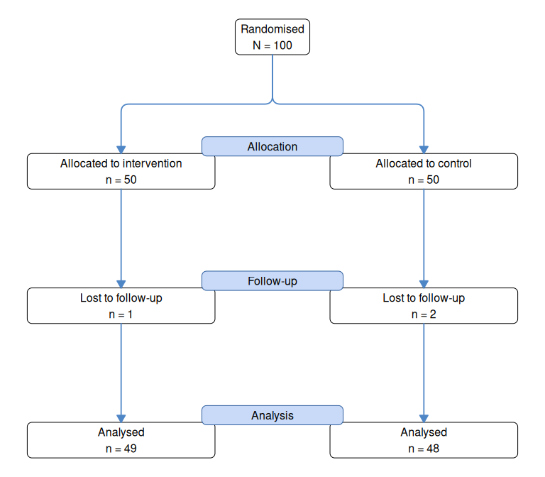

```r
old_opts <- options(boxGrobTxtPadding = unit(2, "mm"))

main_box_gp <- gpar(fill = "white", col = "black", lwd = 1)
heading_gp  <- gpar(fill = "#c8daf7", col = "#2f5f9f", lwd = 1)
con_gp      <- gpar(col = "#4f86c6", fill = "#4f86c6", lwd = 1.8)
side_width  <- unit(70, "mm")

flowchart(
  rando = boxGrob("Randomised\nN = 100", box_gp = main_box_gp),
  groups = list(
    boxGrob("Allocated to intervention\nn = 50",
            width = side_width, box_gp = main_box_gp),
    boxGrob("Allocated to control\nn = 50",
            width = side_width, box_gp = main_box_gp)
  ),
  followup = list(
    boxGrob("Lost to follow-up\nn = 1",
            width = side_width, box_gp = main_box_gp),
    boxGrob("Lost to follow-up\nn = 2",
            width = side_width, box_gp = main_box_gp)
  ),
  analysis = list(
    boxGrob("Analysed\nn = 49",
            width = side_width, box_gp = main_box_gp),
    boxGrob("Analysed\nn = 48",
            width = side_width, box_gp = main_box_gp)
  )
) |>
  spread(axis = "y", margin = unit(0.04, "npc")) |>
  # Spread each stage's arms within the viewport, leaving an outer margin —
  # this gives the two arms a clear central gap for the labels to sit in
  spread(subelement = "groups",   axis = "x", margin = unit(0.05, "npc")) |>
  spread(subelement = "followup", axis = "x", margin = unit(0.05, "npc")) |>
  spread(subelement = "analysis", axis = "x", margin = unit(0.05, "npc")) |>
  # One call per stage: centred between the arms, slightly above, drawn on top
  phaseLabel("groups",   "Allocation", box_gp = heading_gp) |>
  phaseLabel("followup", "Follow-up",  box_gp = heading_gp) |>
  phaseLabel("analysis", "Analysis",   box_gp = heading_gp) |>
  connect("rando",    "groups",   type = "N", lty_gp = con_gp, arrow_size = 3,
          smooth = TRUE) |>
  connect("groups",   "followup", type = "v", lty_gp = con_gp, arrow_size = 3) |>
  connect("followup", "analysis", type = "v", lty_gp = con_gp, arrow_size = 3)
```

```r
options(old_opts)
```